GROUP MEMBERS: SAI PRATEEK ATLURI, SATHWIKA SUDDALA

# **PROBLEM STATEMENT:**

The problem statement seeks to determine the likelihood of survival for individuals aboard the sinking Titanic and the specific characteristics that influenced their survival. The main goal is to analyze attributes such as age, socio-economic class, gender, and cabin allocation and understand the relationships between these attributes and their impact on the passengers' survival.

# **DATA POPULATION:**

The data population in this problem refers to the passengers who are on the titanic at the time of disaster. This population consists of **2,224 passengers and crew members** who were onboard the ship when it sank on April 15, 1912.

# **Kaggle account:** Sathwika Suddala

```python
from google.colab import drive
drive.mount('/content/drive')
```

```python
%cd '/content/drive/MyDrive/BigData/project'
```

```
/content/drive/MyDrive/BigData/project
```

```python
import os
import pandas as pd
import numpy as np
import matplotlib.pyplot as plt
import seaborn as sns
```

```python
train_file=('train.csv')
with open(train_file, "r") as f:
    for i in range(20):
        print(i, "\t", repr(f.readline()))
```

```
0 	 'PassengerId,Survived,Pclass,Name,Sex,Age,SibSp,Parch,Ticket,Fare,Cabin,Embarked\n'
1 	 '1,0,3,"Braund, Mr. Owen Harris",male,22,1,0,A/5 21171,7.25,,S\n'
2 	 '2,1,1,"Cumings, Mrs. John Bradley (Florence Briggs Thayer)",female,38,1,0,PC 17599,71.2833,C85,C\n'
3 	 '3,1,3,"Heikkinen, Miss. Laina",female,26,0,0,STON/O2. 3101282,7.925,,S\n'
4 	 '4,1,1,"Futrelle, Mrs. Jacques Heath (Lily May Peel)",female,35,1,0,113803,53.1,C123,S\n'
5 	 '5,0,3,"Allen, Mr. William Henry",male,35,0,0,373450,8.05,,S\n'
6 	 '6,0,3,"Moran, Mr. James",male,,0,0,330877,8.4583,,Q\n'
7 	 '7,0,1,"McCarthy, Mr. Timothy J",male,54,0,0,17463,51.8625,E46,S\n'
8 	 '8,0,3,"Palsson, Master. Gosta Leonard",male,2,3,1,349909,21.075,,S\n'
9 	 '9,1,3,"Johnson, Mrs. Oscar W (Elisabeth Vilhelmina Berg)",female,27,0,2,347742,11.1333,,S\n'
10 	 '10,1,2,"Nasser, Mrs. Nicholas (Adele Achem)",female,14,1,0,237736,30.0708,,C\n'
11 	 '11,1,3,"Sandstrom, Miss. Marguerite Rut",female,4,1,1,PP 9549,16.7,G6,S\n'
12 	 '12,1,1,"Bonnell, Miss. Elizabeth",female,58,0,0,113783,26.55,C103,S\n'
13 	 '13,0,3,"Saundercock, Mr. William Henry",male,20,0,0,A/5. 2151,8.05,,S\n'
14 	 '14,0,3,"Andersson, Mr. Anders Johan",male,39,1,5,347082,31.275,,S\n'
15 	 '15,0,3,"Vestrom, Miss. Hulda Amanda Adolfina",female,14,0,0,350406,7.8542,,S\n'
16 	 '16,1,2,"Hewlett, Mrs. (Mary D Kingcome) ",female,55,0,0,248706,16,,S\n'
17 	 '17,0,3,"Rice, Master. Eugene",male,2,4,1,382652,29.125,,Q\n'
18 	 '18,1,2,"Williams, Mr. Charles Eugene",male,,0,0,244373,13,,S\n'
19 	 '19,0,3,"Vander Planke, Mrs. Julius (Emelia Maria Vandemoortele)",female,31,1,0,345763,18,,S\n'
```

```python
test_file=('test.csv')
with open(test_file, "r") as f:
    for i in range(20):
        print(i, "\t", repr(f.readline()))
```

```
0 	 'PassengerId,Pclass,Name,Sex,Age,SibSp,Parch,Ticket,Fare,Cabin,Embarked\n'
1 	 '892,3,"Kelly, Mr. James",male,34.5,0,0,330911,7.8292,,Q\n'
2 	 '893,3,"Wilkes, Mrs. James (Ellen Needs)",female,47,1,0,363272,7,,S\n'
3 	 '894,2,"Myles, Mr. Thomas Francis",male,62,0,0,240276,9.6875,,Q\n'
4 	 '895,3,"Wirz, Mr. Albert",male,27,0,0,315154,8.6625,,S\n'
5 	 '896,3,"Hirvonen, Mrs. Alexander (Helga E Lindqvist)",female,22,1,1,3101298,12.2875,,S\n'
6 	 '897,3,"Svensson, Mr. Johan Cervin",male,14,0,0,7538,9.225,,S\n'
7 	 '898,3,"Connolly, Miss. Kate",female,30,0,0,330972,7.6292,,Q\n'
8 	 '899,2,"Caldwell, Mr. Albert Francis",male,26,1,1,248738,29,,S\n'
9 	 '900,3,"Abrahim, Mrs. Joseph (Sophie Halaut Easu)",female,18,0,0,2657,7.2292,,C\n'
10 	 '901,3,"Davies, Mr. John Samuel",male,21,2,0,A/4 48871,24.15,,S\n'
11 	 '902,3,"Ilieff, Mr. Ylio",male,,0,0,349220,7.8958,,S\n'
12 	 '903,1,"Jones, Mr. Charles Cresson",male,46,0,0,694,26,,S\n'
13 	 '904,1,"Snyder, Mrs. John Pillsbury (Nelle Stevenson)",female,23,1,0,21228,82.2667,B45,S\n'
14 	 '905,2,"Howard, Mr. Benjamin",male,63,1,0,24065,26,,S\n'
15 	 '906,1,"Chaffee, Mrs. Herbert Fuller (Carrie Constance Toogood)",female,47,1,0,W.E.P. 5734,61.175,E31,S\n'
16 	 '907,2,"del Carlo, Mrs. Sebastiano (Argenia Genovesi)",female,24,1,0,SC/PARIS 2167,27.7208,,C\n'
17 	 '908,2,"Keane, Mr. Daniel",male,35,0,0,233734,12.35,,Q\n'
18 	 '909,3,"Assaf, Mr. Gerios",male,21,0,0,2692,7.225,,C\n'
19 	 '910,3,"Ilmakangas, Miss. Ida Livija",female,27,1,0,STON/O2. 3101270,7.925,,S\n'
```

# **DATA**

**Loading the data into Data Frames**

```python
train=pd.read_csv('train.csv')
train.head()
```

|  | PassengerId | Survived | Pclass | Name | Sex | Age | SibSp | Parch | Ticket | Fare | Cabin | Embarked |
| --- | --- | --- | --- | --- | --- | --- | --- | --- | --- | --- | --- | --- |
| 0 | 1 | 0 | 3 | Braund, Mr. Owen Harris | male | 22.0 | 1 | 0 | A/5 21171 | 7.2500 | NaN | S |
| 1 | 2 | 1 | 1 | Cumings, Mrs. John Bradley (Florence Briggs Th... | female | 38.0 | 1 | 0 | PC 17599 | 71.2833 | C85 | C |
| 2 | 3 | 1 | 3 | Heikkinen, Miss. Laina | female | 26.0 | 0 | 0 | STON/O2. 3101282 | 7.9250 | NaN | S |
| 3 | 4 | 1 | 1 | Futrelle, Mrs. Jacques Heath (Lily May Peel) | female | 35.0 | 1 | 0 | 113803 | 53.1000 | C123 | S |
| 4 | 5 | 0 | 3 | Allen, Mr. William Henry | male | 35.0 | 0 | 0 | 373450 | 8.0500 | NaN | S |

```python
train.info()
```

```
<class 'pandas.core.frame.DataFrame'>
RangeIndex: 891 entries, 0 to 890
Data columns (total 12 columns):
 #   Column       Non-Null Count  Dtype
---  ------       --------------  -----
 0   PassengerId  891 non-null    int64
 1   Survived     891 non-null    int64
 2   Pclass       891 non-null    int64
 3   Name         891 non-null    object
 4   Sex          891 non-null    object
 5   Age          714 non-null    float64
 6   SibSp        891 non-null    int64
 7   Parch        891 non-null    int64
 8   Ticket       891 non-null    object
 9   Fare         891 non-null    float64
 10  Cabin        204 non-null    object
 11  Embarked     889 non-null    object
dtypes: float64(2), int64(5), object(5)
memory usage: 83.7+ KB
```

```python
test=pd.read_csv('test.csv')
test.head()
```

|  | PassengerId | Pclass | Name | Sex | Age | SibSp | Parch | Ticket | Fare | Cabin | Embarked |
| --- | --- | --- | --- | --- | --- | --- | --- | --- | --- | --- | --- |
| 0 | 892 | 3 | Kelly, Mr. James | male | 34.5 | 0 | 0 | 330911 | 7.8292 | NaN | Q |
| 1 | 893 | 3 | Wilkes, Mrs. James (Ellen Needs) | female | 47.0 | 1 | 0 | 363272 | 7.0000 | NaN | S |
| 2 | 894 | 2 | Myles, Mr. Thomas Francis | male | 62.0 | 0 | 0 | 240276 | 9.6875 | NaN | Q |
| 3 | 895 | 3 | Wirz, Mr. Albert | male | 27.0 | 0 | 0 | 315154 | 8.6625 | NaN | S |
| 4 | 896 | 3 | Hirvonen, Mrs. Alexander (Helga E Lindqvist) | female | 22.0 | 1 | 1 | 3101298 | 12.2875 | NaN | S |

```python
test.info()
```

```
<class 'pandas.core.frame.DataFrame'>
RangeIndex: 418 entries, 0 to 417
Data columns (total 11 columns):
 #   Column       Non-Null Count  Dtype
---  ------       --------------  -----
 0   PassengerId  418 non-null    int64
 1   Pclass       418 non-null    int64
 2   Name         418 non-null    object
 3   Sex          418 non-null    object
 4   Age          332 non-null    float64
 5   SibSp        418 non-null    int64
 6   Parch        418 non-null    int64
 7   Ticket       418 non-null    object
 8   Fare         417 non-null    float64
 9   Cabin        91 non-null     object
 10  Embarked     418 non-null    object
dtypes: float64(2), int64(4), object(5)
memory usage: 36.0+ KB
```

# Description of Data

**PassengerId:** each row represents a unique passenger(891). And it is Int data type. this number is unique for every passenger.

**Survived**:it has only 2 values 0 or 1 either they survived or not. And it is Int data type.

**Pclass:** this column represents socio-economic class of each passenger either 1st or 2nd or 3rd. And it is Int data type.

**Name:** This column represents name of the passenger. And it is String data type. And it is String data type.

**Sex:** This column refers to the gender of passenger either male or female. And granularity is at the individual passenger level. And it is String data type.

**SibSp:** This column refers to number of siblings or spouses in the ship for every passenger. And it is Int data type.

**Parch:** This column refers to the number of parents or children in the ship for every passenger. And it is Int data type.

**Cabin:** This column refers to the cabin number and it had many missing values. And it is String data type.

**Embarked:** This column refers to port of embarkation where it had 3 options C= Cherbourg, Q = Queenstown, S = Southampton for every passenger. But it had 2 missing values. And it is String data type.

# **DATA** **WRANGLING**

#### Exploring the data

Now we want to understand its:

- **Structure** -- the table’s rows and columns.
- **Granularity** -- describe what each row in the table represents
- **Scope** -- Do the data match your understanding of the population?
- **Temporality** -- how is the data situated in time
- **Faithfulness** -- how well does the data capture "reality"

# **Structure:**

[figure not shown]

```python
X = ['Row Length','Column Length']
train_shape= train.shape
test_shape= test.shape

X_axis = np.arange(len(X))

plt.bar(X_axis - 0.2, train_shape, 0.4, label = 'Train')
plt.bar(X_axis + 0.2, test_shape, 0.4, label = 'Test')

plt.xticks(X_axis, X)
plt.xlabel("Groups")
plt.ylabel("Number of Students")
plt.title("Number of Students in each group")
plt.legend()
plt.show()
```

Structure of train data is rectangular format i.e,

- **Rows** -- 891
- **Columns** -- 12

Structure of test data is rectangular format i.e,

- **Rows** -- 418
- **Columns** -- 11

# **GRANULARITY**

Granularity refers to "describe what each row in the table represents".

**Bar plot to show the survival rate for passengers in each passenger class.**

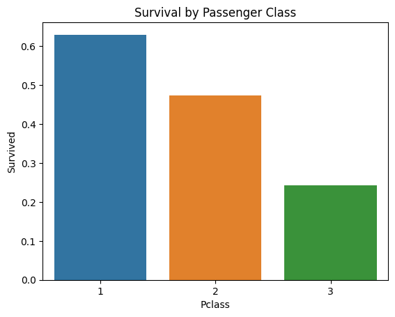

```python
sns.barplot(data=train, x='Pclass', y='Survived', errorbar=None)
plt.title('Survival by Passenger Class')
plt.show()
```

**Bar plot to show the survival rate for male and female passengers.**

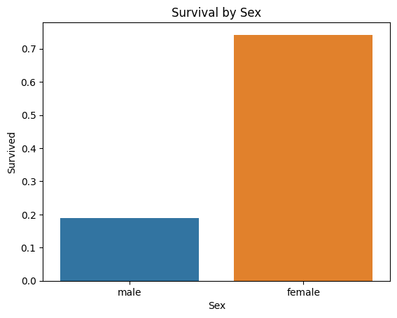

```python
sns.barplot(data=train, x='Sex', y='Survived', errorbar=None)
plt.title('Survival by Sex')
plt.show()
```

**Bar plot to show the survival rate by stations passengers have embarked on.**

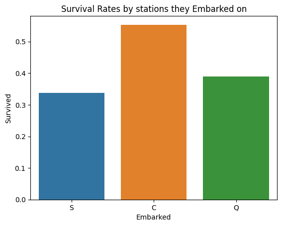

```python
sns.barplot(data=train, x='Embarked', y='Survived', errorbar=None)
plt.title('Survival Rates by stations they Embarked on')
plt.show()
```

```python
train.head(2)
```

|  | PassengerId | Survived | Pclass | Name | Sex | Age | SibSp | Parch | Ticket | Fare | Cabin | Embarked |
| --- | --- | --- | --- | --- | --- | --- | --- | --- | --- | --- | --- | --- |
| 0 | 1 | 0 | 3 | Braund, Mr. Owen Harris | male | 22.0 | 1 | 0 | A/5 21171 | 7.2500 | NaN | S |
| 1 | 2 | 1 | 1 | Cumings, Mrs. John Bradley (Florence Briggs Th... | female | 38.0 | 1 | 0 | PC 17599 | 71.2833 | C85 | C |

in the Titanic dataset:

- The granularity is at the level of individual passengers.
- Every row represents a single passenger.
- The data captures detailed information about each passenger's attributes.
- The investigation of how various attributes and factors affected each passenger's chance of survival is made possible by this level of granularity.

# **SCOPE**

The dataset is mainly concerned with characteristics that are important for analysing survival and associated variables. There is no other data regarding the lives of the individuals or their trip plans provided. Also scope refers to how incomplete is the data.

**Data Quality Assessment:**

If there are many missing values (NAN's), it can indicate data quality issues or areas that need attention. The count of non-null values helps analyse the data's quality.

It's important to count how many data values are not empty in each column when working with data. This helps with tasks like filling in missing values or choosing which columns to keep or remove.

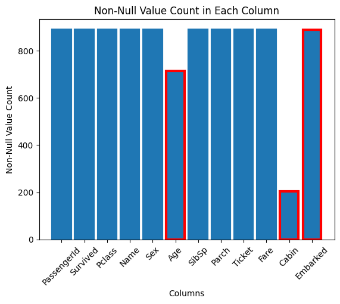

```python
non_null_counts=train.count()
colors = ['red' if count < train.shape[0] else 'tab:blue' for count in non_null_counts]
plt.bar(non_null_counts.index, non_null_counts.values,edgecolor=colors, linewidth=3)
plt.xlabel("Columns")
plt.ylabel("Non-Null Value Count")
plt.title("Non-Null Value Count in Each Column")
plt.xticks(rotation=45)
plt.show()
```

Above bar plot shows the Non-null value count in Each column. The columns which are marked red have missing values.

**MISSING VALUES:**

The attribute Age has missing values out of 891 it had 714 values.

The attribute Cabin has a lot of missing values, out of 891 it had only 204 values which makes it difficult to predict the survival of passenger.

The attribute Embarked has 2 missing values.

# Does my data cover my area of interest?

Yes the data covers my interest in finding the survival of a passenger.

# Is my data too expansive?

No, the data we have is not expansive. as it has the details of passangers which is exactly enough for us to predict survival of a passenger.

# **Temporality**

The Titanic dataset, primarily captures a specific historical event: the sinking of the RMS Titanic during its maiden voyage in April 1912. In this context, **the temporality of the Titanic dataset is tied to this singular event**.

**Date of the Disaster**: The most significant temporal aspect of the Titanic dataset is the date of the disaster, which occurred on April 15, 1912. This date is crucial for understanding the context of the data and the sequence of events surrounding the sinking.

**Age**: The ages of passengers, though not timestamp data, provide a sense of the life stage of each passenger at the time of the voyage.

The Titanic dataset is **not a time series dataset** in the typical sense. It doesn't include data recorded at regular time intervals, and it is not designed for time series analysis. Instead, the temporal aspects of the dataset are focused on the context and timing of the Titanic disaster, which is the central event in the data.

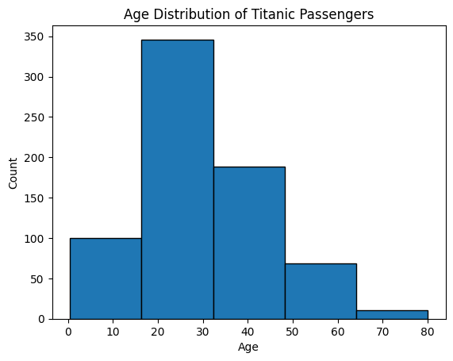

```python
age_dis=train['Age']
age_dis=age_dis.dropna()
# Create a histogram to plot the age distribution
plt.hist(age_dis, bins=5, edgecolor='k')
plt.xlabel('Age')
plt.ylabel('Count')
plt.title('Age Distribution of Titanic Passengers')
plt.show()
```

# **FAITHFULNESS**

The faithfulness of Titanic dataset is highly considered true because it comes from historical records and official Titanic disaster documents. But, there might be problems like missing information or values in the data. So, analysts should be careful and check the data to make sure it's accurate for their specific work.

**Handling missing values**

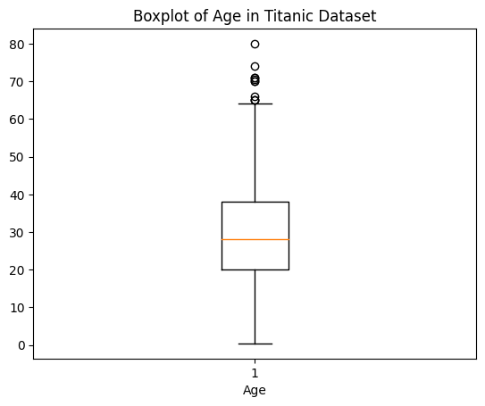

```python
plt.boxplot(age_dis)  # vert=False for a horizontal boxplot
plt.title('Boxplot of Age in Titanic Dataset')
plt.xlabel('Age')
plt.show()
```

**The box plot shows outliers in the "Age" column of the Titanic dataset, it's a good practice to consider imputing missing values with the median rather than the mean.**

```python
median=train['Age'].median()
train['Age'].fillna(value=median, inplace=True)
train.head()
```

|  | PassengerId | Survived | Pclass | Name | Sex | Age | SibSp | Parch | Ticket | Fare | Cabin | Embarked |
| --- | --- | --- | --- | --- | --- | --- | --- | --- | --- | --- | --- | --- |
| 0 | 1 | 0 | 3 | Braund, Mr. Owen Harris | male | 22.0 | 1 | 0 | A/5 21171 | 7.2500 | NaN | S |
| 1 | 2 | 1 | 1 | Cumings, Mrs. John Bradley (Florence Briggs Th... | female | 38.0 | 1 | 0 | PC 17599 | 71.2833 | C85 | C |
| 2 | 3 | 1 | 3 | Heikkinen, Miss. Laina | female | 26.0 | 0 | 0 | STON/O2. 3101282 | 7.9250 | NaN | S |
| 3 | 4 | 1 | 1 | Futrelle, Mrs. Jacques Heath (Lily May Peel) | female | 35.0 | 1 | 0 | 113803 | 53.1000 | C123 | S |
| 4 | 5 | 0 | 3 | Allen, Mr. William Henry | male | 35.0 | 0 | 0 | 373450 | 8.0500 | NaN | S |

**Replacing missing values in Embarked column with most frequent value.**

```python
train['Embarked'].value_counts()
```

```
S    644
C    168
Q     77
Name: Embarked, dtype: int64
```

```python
train['Embarked'].fillna(train['Embarked'].mode()[0], inplace=True)
```

# **Data Representative**

No, the data obtained doesnot represent whole population of the incident i.e, 2224 people. As it excludes information about the crew. Crew members made up a significant portion of the Titanic's population. From the dataset attributes we can clearly understand that it only represents the passangers details

The data only represents passengers population not the whole data population.

# **Assumptions**

# **Sampling Method**

The difference in the data population (2224 in the entire Titanic population vs. 891 in the provided data) suggests that a sampling method was likely used during data collection.

The population is divided into subgroups or strata, and a random sample is collected from each stratum. This method is often used to ensure that the sample represents different segments of the population. In the context of the Titanic dataset, **Stratified Sampling** could have been used to obtain a representative sample of passengers.

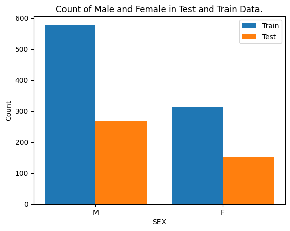

```python
X = ['M','F']
em_train=train['Sex'].value_counts().tolist()
em_test=test['Sex'].value_counts().tolist()


X_axis = np.arange(len(X))

plt.bar(X_axis - 0.2, em_train, 0.4, label = 'Train')
plt.bar(X_axis + 0.2, em_test, 0.4, label = 'Test')

plt.xticks(X_axis, X)
plt.xlabel("SEX")
plt.ylabel("Count")
plt.title("Count of Male and Female in Test and Train Data.")
plt.legend()
plt.show()
```

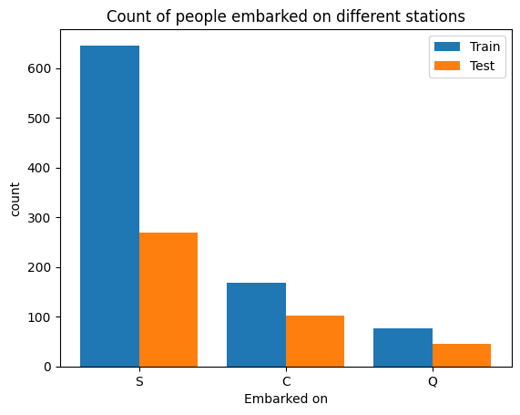

```python
X = ['S','C','Q']
em_train=train['Embarked'].value_counts().tolist()
em_test=test['Embarked'].value_counts().tolist()


X_axis = np.arange(len(X))

plt.bar(X_axis - 0.2, em_train, 0.4, label = 'Train')
plt.bar(X_axis + 0.2, em_test, 0.4, label = 'Test')

plt.xticks(X_axis, X)
plt.xlabel("Embarked on")
plt.ylabel("count")
plt.title("Count of people embarked on different stations")
plt.legend()
plt.show()
```

**As the attributes' ratios (proportions) are similar in both the training and test datasets, it may suggest that the original data source was stratified during the splitting of data into these trainand test subsets.**

```python
!pip install nbconvert
```

```python
%shell jupyter nbconvert --to html Titanic.ipynb
```